# MooseWeb3 | Using R Markdown to Build HTML: A Complete Guide

MooseWeb3 · Practical HTML Learning Guide

2026-08-12

# Learning objectives

This file is both a tutorial and a working R Markdown example that can be rendered directly to HTML. By the end, you will be able to:

- understand how `.Rmd`, Markdown, HTML, CSS, R, knitr, and Pandoc work together;
- create a web report with navigation, numbered sections, code, plots, tables, and raw HTML;
- generate an `.html` file from RStudio, an R command, or a system terminal;
- control code visibility, resource embedding, and page styling;
- troubleshoot encoding, image paths, missing packages, and rendering failures.

**Fastest path:** Install R and RStudio, run `install.packages(“rmarkdown”)` in R, open this file, and click `Knit`. R Markdown will create `HTML_RMarkdown_Guide_en.html` in the same directory.

# 1. HTML, Markdown, and R Markdown

## 1.1 What is HTML?

HTML (HyperText Markup Language) describes the **structure and meaning** of a web page. A browser reads HTML elements and displays them as headings, paragraphs, links, images, tables, and other content.

```html
<!doctype html>
<html lang="en">
  <head>
    <meta charset="utf-8">
    <title>My page</title>
  </head>
  <body>
    <h1>Hello, HTML!</h1>
    <p>This is a paragraph.</p>
    <a href="https://www.r-project.org/">Visit the R Project</a>
  </body>
</html>
```

Common HTML elements include:

| Element | Purpose | Example |
| --- | --- | --- |
| `<h1>`—`<h6>` | Six heading levels | `<h2>Methods</h2>` |
| `<p>` | Paragraph | `<p>Body text</p>` |
| `<a>` | Link | `<a href="...">Link text</a>` |
| `<img>` | Image | `<img src="plot.png" alt="A plot">` |
| `<ul>` / `<ol>` | Unordered/ordered list | `<ul><li>Item</li></ul>` |
| `<table>` | Table | `<table>...</table>` |
| `<div>` / `<span>` | Block/inline container | Often styled with CSS |
| `<code>` / `<pre>` | Inline/preformatted code | Displays code |

HTML commonly works with two related technologies: **CSS** controls presentation, while **JavaScript** adds behavior and interaction.

## 1.2 What is Markdown?

Markdown uses lightweight plain-text symbols for common formatting. It is generally easier to read and maintain than hand-written HTML. For example:

```markdown
# Level-one heading

This paragraph contains **bold**, *italic*, and `inline code` text.

- Apple
- Banana

[The R Project](https://www.r-project.org/)
```

## 1.3 What is R Markdown?

An R Markdown file ends in `.Rmd` and combines three kinds of content:

1. YAML: document metadata and output settings;
2. Markdown/HTML: explanation and page structure;
3. R code chunks: analysis that automatically inserts results, tables, and plots.

The rendering pipeline is:

```
.Rmd file
   │
   ├─ knitr runs R code and creates Markdown
   │
   └─ Pandoc converts Markdown to HTML
                         │
                         └─ a browser opens the .html file
```

Because code, output, and explanation live in one source file, R Markdown is useful for reproducible analysis, course notes, lab reports, and data presentations.

# 2. Set up your environment

## 2.1 Install the software

The recommended setup is:

1. **R**, which runs the code;
2. **RStudio Desktop**, which provides an editor and a Knit button;
3. the **rmarkdown package**, which manages the rendering pipeline.

Install the required packages in the R Console:

```r
install.packages(c("rmarkdown", "knitr"))
```

Check the environment:

```r
R.version.string
packageVersion("rmarkdown")
rmarkdown::pandoc_available()
rmarkdown::pandoc_version()
```

RStudio normally bundles Pandoc, so a separate Pandoc installation is usually unnecessary.

## 2.2 Recommended project structure

```
my-report/
├─ report.Rmd
├─ data/
│  └─ observations.csv
├─ images/
│  └─ logo.png
├─ styles.css
└─ output/
```

Resolve paths relative to the `.Rmd` file or RStudio Project. Prefer relative paths with forward slashes, such as `images/logo.png`, so the project remains portable across computers.

# 3. Anatomy of an R Markdown file

A minimal but complete `.Rmd` file looks like this:

````markdown
---
title: "My first HTML report"
author: "Your name"
date: "`r Sys.Date()`"
output: html_document
---

# Introduction

This is the body text.

```{r}
summary(cars)
```
````

## 3.1 The YAML header

YAML is placed between the two `---` lines at the very top of the file. Indentation must use spaces, not tabs. Quote a text value if it contains another colon.

This guide uses a more complete HTML configuration:

```yaml
output:
  html_document:
    toc: true              # Build a table of contents
    toc_float: true        # Keep it visible while scrolling
    number_sections: true  # Number sections automatically
    theme: flatly          # Bootstrap theme
    highlight: tango       # Syntax highlighting style
    code_folding: show     # Make code collapsible; initially open
    df_print: paged        # Paginate data frames
    self_contained: true   # Embed common assets in one HTML file
```

Other built-in themes include `default`, `cerulean`, `cosmo`, `darkly`, `journal`, `readable`, `sandstone`, and `yeti`.

## 3.2 Body text and headings

Use hash characters for headings. More hashes mean a deeper heading level:

```markdown
# Level one
## Level two
### Level three
```

Keep heading levels logically nested. With `toc: true`, headings are added to the table of contents automatically.

# 4. Essential Markdown syntax

## 4.1 Text formatting

```markdown
**Bold**
*Italic*
~~Strikethrough~~
`Inline code`

> This is a block quotation.

Horizontal rule:

---
```

Rendered examples: **bold**, *italic*, strikethrough, and `inline code`.

## 4.2 Lists

```markdown
- Unordered item
  - Nested item
- Another item

1. First step
2. Second step

- [x] Complete
- [ ] To do
```

## 4.3 Links and images

```markdown
[Link text](https://example.com)

![Alternative text](images/chart.png)
```

Alternative text should briefly communicate the meaning of an image for accessibility. Use an R chunk when you need to control image size:

````markdown
```{r, echo=FALSE, out.width="70%", fig.align="center"}
knitr::include_graphics("images/chart.png")
```
````

## 4.4 Markdown tables

```markdown
| Name | Score | Status |
|:---|---:|:---:|
| Alex | 92 | Pass |
| Sam | 87 | Pass |
```

Colons control alignment: a left colon aligns left, two colons center, and a right colon aligns right.

# 5. R code and dynamic output

## 5.1 Code chunks

An R code chunk begins and ends with three backticks. `{r chunk-name}` identifies the language and gives the chunk a name.

```r
values <- c(12, 15, 18, 21, 24)
c(
  mean = mean(values),
  median = median(values),
  standard_deviation = sd(values)
)
```

```
##               mean             median standard_deviation
##          18.000000          18.000000           4.743416
```

Every chunk name must be unique. Letters, numbers, hyphens, and underscores are the safest characters to use.

## 5.2 Common chunk options

| Option | Effect |
| --- | --- |
| `echo=FALSE` | Run code but hide its source |
| `eval=FALSE` | Show code without running it |
| `include=FALSE` | Run code but hide both code and output |
| `results='hide'` | Show code but hide its text output |
| `message=FALSE` | Hide package and status messages |
| `warning=FALSE` | Hide warnings; enable them while debugging |
| `error=TRUE` | Display errors and continue; use cautiously in final reports |
| `fig.width=7` | Set plot width in inches |
| `fig.height=4` | Set plot height in inches |
| `fig.cap='Caption'` | Add a figure caption |
| `cache=TRUE` | Cache expensive calculations; rebuild when dependencies change |

The following chunk runs and displays a plot without showing its source in the HTML:

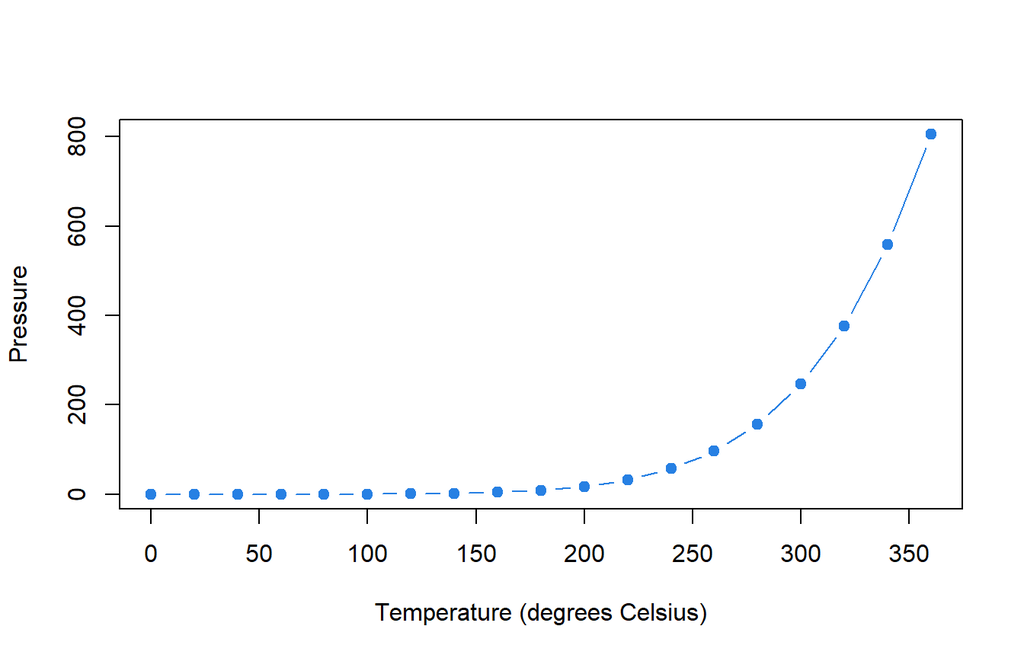

Temperature and mercury vapor pressure

## 5.3 Inline R code

Use `` `r expression` `` inside a sentence to insert a dynamic value. For example, this source:

```markdown
The data set contains `r nrow(iris)` rows and `r ncol(iris)` columns.
```

produces: The data set contains 150 rows and 5 columns.

## 5.4 Generate tables with R

```r
knitr::kable(
  head(iris, 8),
  caption = "The first eight rows of the iris data set",
  digits = 2,
  align = "c"
)
```

The first eight rows of the iris data set

| Sepal.Length | Sepal.Width | Petal.Length | Petal.Width | Species |
| --- | --- | --- | --- | --- |
| 5.1 | 3.5 | 1.4 | 0.2 | setosa |
| 4.9 | 3.0 | 1.4 | 0.2 | setosa |
| 4.7 | 3.2 | 1.3 | 0.2 | setosa |
| 4.6 | 3.1 | 1.5 | 0.2 | setosa |
| 5.0 | 3.6 | 1.4 | 0.2 | setosa |
| 5.4 | 3.9 | 1.7 | 0.4 | setosa |
| 4.6 | 3.4 | 1.4 | 0.3 | setosa |
| 5.0 | 3.4 | 1.5 | 0.2 | setosa |

`knitr::kable()` is sufficient for lightweight tables. Packages such as `kableExtra`, `gt`, and `DT` support more advanced styling, but anyone rendering the document must also install those dependencies.

# 6. Use raw HTML in R Markdown

When the output format is HTML, raw HTML can be written directly in the document body:

```html
<div class="result-box">
  <h4>Analysis result</h4>
  <p>This area was created with raw HTML.</p>
</div>
```

Here is the actual result:

#### Analysis result

This area was created with raw HTML. It can also contain highlighted text and keyboard hints such as `Ctrl` + `S`.

## 6.1 Collapsible content

`<details>` and `<summary>` provide disclosure behavior without JavaScript:

**Click to reveal the note**

Supplementary notes, long code, or an answer can go here.

The source is:

```html
<details>
<summary>Click to reveal the note</summary>
This is the hidden content.
</details>
```

## 6.2 HTML entities and special characters

In raw HTML, `<`, `>`, and `&` have special meanings. Write them as `&lt;`, `&gt;`, and `&amp;` when they should appear literally. Never concatenate untrusted user input directly into HTML, because doing so can create cross-site scripting (XSS) vulnerabilities.

## 6.3 Add CSS

Small amounts of CSS can be placed in a `<style>` element, as this file demonstrates. For larger projects, use an external style sheet:

```yaml
output:
  html_document:
    css: styles.css
```

Example `styles.css`:

```css
body {
  max-width: 1100px;
  margin: auto;
  font-family: system-ui, sans-serif;
}

h1, h2, h3 { color: #174a7e; }
.important { background: #fff3cd; padding: 1rem; }
```

Then use the class in the `.Rmd` file:

```html
<div class="important">Important information goes here.</div>
```

**Compatibility note:** Raw HTML and CSS generally apply only to HTML output. If the same source must also produce PDF or Word, prefer Markdown where possible or provide conditional content for each format.

# 7. Three ways to generate HTML

## 7.1 Click Knit in RStudio

1. Open the `.Rmd` file in RStudio;
2. save the file;
3. click **Knit** above the editor;
4. wait for rendering to finish;
5. inspect the result in a browser or the RStudio Viewer. The `.html` file appears beside the source file.

The usual shortcut is `Ctrl` + `Shift` + `K` on Windows/Linux or `Cmd` + `Shift` + `K` on macOS.

## 7.2 Render from the R Console

```r
rmarkdown::render("HTML_RMarkdown_Guide_en.Rmd")
```

Specify the output file and directory when needed:

```r
rmarkdown::render(
  input = "HTML_RMarkdown_Guide_en.Rmd",
  output_file = "guide-en.html",
  output_dir = "output",
  encoding = "UTF-8"
)
```

Rendering normally replaces an existing HTML file with the same name. Do not maintain long-lived changes by editing the generated HTML; edit the `.Rmd` source and render it again.

## 7.3 Render from a system terminal

Run this command in the project directory:

```bash
Rscript -e "rmarkdown::render('HTML_RMarkdown_Guide_en.Rmd', encoding='UTF-8')"
```

This method is useful for automation scripts, scheduled jobs, and continuous integration systems.

# 8. Self-contained HTML and external assets

With `self_contained: true`, R Markdown attempts to encode CSS, JavaScript, and images inside one HTML file. The result is easy to send by email or chat, but the file can become large. Remote iframes, videos, and some specialized widgets may not be fully embedded.

With this setting:

```yaml
self_contained: false
```

R Markdown normally creates a resource directory such as `report_files/`. When publishing or copying the page, keep the HTML file and this directory in the same relative locations.

Practical guidance:

- For one-off sharing and small or medium reports, prefer `self_contained: true`;
- for many images, multi-page sites, or frequent updates, consider `self_contained: false`;
- before publishing, test every relative link and asset path.

# 9. Parameterized reports

Parameters let one template generate reports for different regions, dates, or clients. Define parameters in YAML:

```yaml
---
title: "Parameterized report"
output: html_document
params:
  region: "West"
  report_date: !r Sys.Date()
---
```

Use `params` in the document body:

```markdown
Current region: `r params$region`

Report date: `r params$report_date`
```

Pass new values during rendering:

```r
rmarkdown::render(
  "report.Rmd",
  params = list(region = "North", report_date = as.Date("2026-08-11")),
  output_file = "report-north.html"
)
```

# 10. Interactive HTML content

HTML reports can contain interactive plots and tables. After installing `plotly`, for example:

```r
install.packages("plotly")

library(plotly)
plot_ly(
  data = iris,
  x = ~Sepal.Length,
  y = ~Petal.Length,
  color = ~Species,
  type = "scatter",
  mode = "markers"
)
```

Other HTML Widget packages include `leaflet` for maps, `DT` for interactive tables, and `dygraphs` for time series. These widgets work well in HTML but usually cannot be transferred directly to a static PDF or Word document.

# 11. Build a multi-page HTML site

For several linked pages, create `_site.yml` in the project root:

```yaml
name: "my-notes"
output_dir: "_site"
navbar:
  title: "HTML Notes"
  left:
    - text: "Home"
      href: index.html
    - text: "Guide"
      href: guide.html
output:
  html_document:
    theme: flatly
    css: styles.css
```

Create pages such as `index.Rmd` and `guide.Rmd`, then run:

```r
rmarkdown::render_site()
```

The generated site is stored in `_site/`. Deploy the entire `_site/` directory rather than the `.Rmd` source files.

# 12. Common errors and solutions

## 12.1 YAML parsing errors

**Symptom:** The error points near the top of the document and may contain `mapping values are not allowed`.

**Check:**

- Is there a space after every YAML colon?
- Is indentation consistent?
- Did a tab character slip into the YAML?
- Are titles containing colons, hashes, or special characters quoted?
- Are there opening and closing `---` lines?

## 12.2 Missing files or images

Inspect the working directory used during rendering:

```r
getwd()
file.exists("images/chart.png")
list.files("images")
```

Avoid absolute paths that only work on your computer, such as `C:/Users/name/Desktop/...`.

## 12.3 Missing functions or packages

If R reports `could not find function`, check that the package is installed and loaded:

```r
install.packages("packageName")  # Install once
library(packageName)             # Load in each new session
```

Alternatively, use `package::function()`, as in `knitr::kable()`, without calling `library(knitr)` first.

## 12.4 Encoding problems

- Save the `.Rmd` source as UTF-8;
- set an appropriate `lang` in YAML;
- pass `encoding = "UTF-8"` while rendering;
- choose system fonts that contain the required characters;
- avoid saving the file in a legacy local encoding.

HTML uses Unicode by default. Encoding problems often originate in the source file, imported CSV data, or fonts rather than in HTML itself.

## 12.5 Code works in the Console but Knit fails

Knit normally runs in a clean R session. Objects created temporarily in the Console do not automatically exist there. Put all data imports, package loading, and object creation inside the `.Rmd`, then test the chunks from top to bottom.

## 12.6 Find the failing chunk

The rendering log normally names the failing chunk and reports progress. To diagnose it:

1. Give every chunk a unique, descriptive name;
2. temporarily enable global warnings and messages;
3. run chunks sequentially in a clean session;
4. check the files, objects, and packages required by the failing chunk;
5. fix the cause instead of masking errors with `error=TRUE` in a final report.

# 13. Complete copyable template

The template below depends only on R, rmarkdown, and knitr. Save it as `report.Rmd`:

````markdown
---
title: "Example analysis report"
author: "Your name"
date: "`r format(Sys.Date(), '%Y-%m-%d')`"
lang: en
output:
  html_document:
    toc: true
    number_sections: true
    theme: flatly
    self_contained: true
---

```{r template-setup, include=FALSE}
knitr::opts_chunk$set(
  echo = TRUE,
  message = FALSE,
  warning = FALSE,
  fig.align = "center"
)
```

# Executive summary

This report analyzes the built-in `mtcars` data set, which contains `r nrow(mtcars)` records.

# Data overview

```{r overview}
summary(mtcars[c("mpg", "disp", "hp", "wt")])
```

# Plot

```{r mpg-vs-weight, fig.cap="Vehicle weight and fuel efficiency"}
plot(
  mtcars$wt,
  mtcars$mpg,
  pch = 19,
  col = "steelblue",
  xlab = "Weight (1,000 pounds)",
  ylab = "Miles per gallon"
)
abline(lm(mpg ~ wt, data = mtcars), col = "firebrick", lwd = 2)
```

# Table

```{r table}
knitr::kable(
  head(mtcars[, c("mpg", "disp", "hp", "wt")]),
  digits = 2,
  caption = "Sample data"
)
```

# Conclusion

The prose, values, table, and plot are generated from a single source file.
````

# 14. Pre-render checklist

- YAML indentation is valid and the output is `html_document`;
- the source file uses UTF-8 encoding;
- every R package is installed and either loaded or called with `package::function()`;
- data and images use portable relative paths;
- every chunk runs in order in a clean R session;
- no passwords, API keys, or private data appear in the source or output;
- plots have useful labels/captions and images have alternative text;
- the HTML works in common browsers and at different window widths;
- if `self_contained: false`, the resource directory is published with the HTML;
- the `.Rmd` remains the source of truth instead of the generated HTML.

# 15. Where to go next

After mastering the basics, you can explore:

- `bookdown` for cross-references, figure numbering, and long-form documents;
- `flexdashboard` for dashboards;
- Shiny for interactive applications with server-side logic;
- Quarto for newer multi-format documents, websites, and presentations;
- Git for versioning `.Rmd` source files and automation for publishing HTML.

**Core principle:** Keep content, code, and configuration in the `.Rmd` source, and treat `.html` as a reproducible output. Re-render after editing the source so the analysis and explanation always stay synchronized.